# Tema 3. Flujo de datos

En el siguiente código, asignamos la especie de pingüino al eje X, pero aún **no especificamos ninguna geometría** para representar visualmente estos datos.

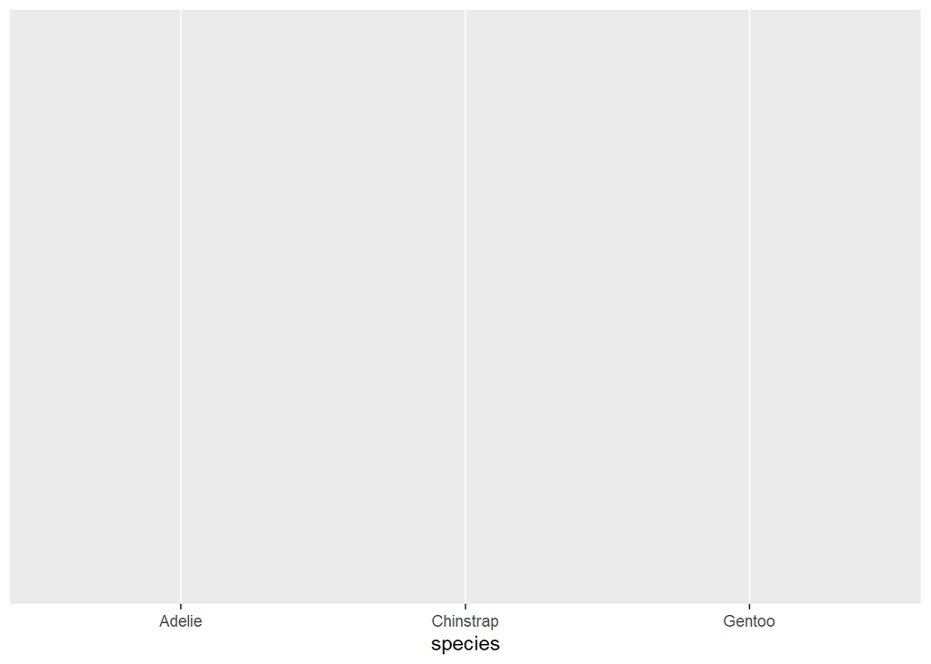

Variables añadidas pero sin representar aún la geometría

```r
 ggplot(data = penguins,
        aes(x = species))
```

Aquí estamos diciendo: eje X → Especie de pingüino (*species*). Por ahora seguimos sin dibujar nada, pero **el gráfico ya sabe qué representar**.

Las **geometrías** (funciones que comienzan con `geom_`) son las capas que realmente dibujan elementos en el gráfico. Cada tipo de gráfico corresponde a una geometría específica. La elección de la geometría depende del tipo de datos y del mensaje que queremos comunicar.

Ahora añadimos una geometría (`geom_bar`) de barras al gráfico anterior para crear un gráfico que nos muestre el número de ejemplares que tenemos de cada especie de pingüino en nuestra base de datos.

[output not shown]

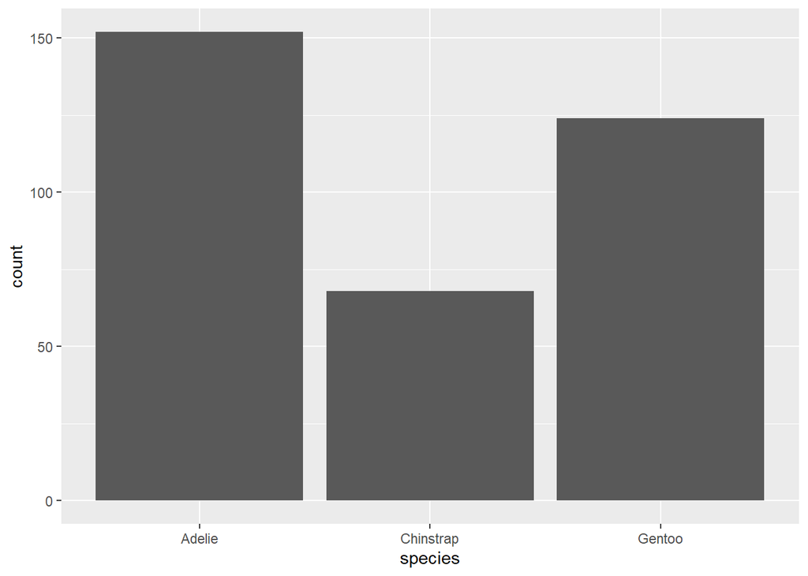

Representación del conteo de individuos por especie en nuestra base de datos

```r
ggplot(penguins, aes(x = species)) +
   geom_bar()
```

#### 1.0.0.1 📝Ejercicio: Creación de gráficos

Crea dos gráficos: uno que muestre el número de individuos por especie y otro el número de individuos por isla. Crea otro gráfico con la variable *body_mass_g* que muestre la distribución de la variable.

- ¿Qué diferencias observas entre representar una variable categórica y una variable continua?
- ¿Qué aspectos del gráfico mejorarías para hacerlo más claro?

## 1.1 Los básicos y los avanzados: la estética vs. el mapeado, facetas

El **mapping** determina el tamaño, la transparenciad e los puntos basados en los valores de la variable especificada, y lo especificamos dentro del argumento `aes()`.

El **setting** determina el tamaño, la transparencia, etc. sin basarse en los valores de la variable especificada. En este caso va en la función `geom_poing` (pero puede ser del tipo `geom_*()` porque aprenderemos más formas a lo largo de la visualización).

### 1.1.1 Etiquetas (`labs()`)

Las etiquetas son elementos fundamentales para mejorar la claridad y comprensión de los gráficos. La función `labs()` nos permite personalizar todos los textos descriptivos de un gráfico, haciéndolo autónomo y comprensible sin necesidad de referencias externas. Es crucial para crear visualizaciones profesionales que puedan ser interpretadas correctamente fuera de su contexto original, por ejemplo en una presentación de ppt.

Comenzamos creando un gráfico base de diagramas de caja que relaciona la especie de pingüinos con su masa corporal. Este gráfico servirá como punto de partida para demostrar cómo las etiquetas mejoran la comunicación de la información.

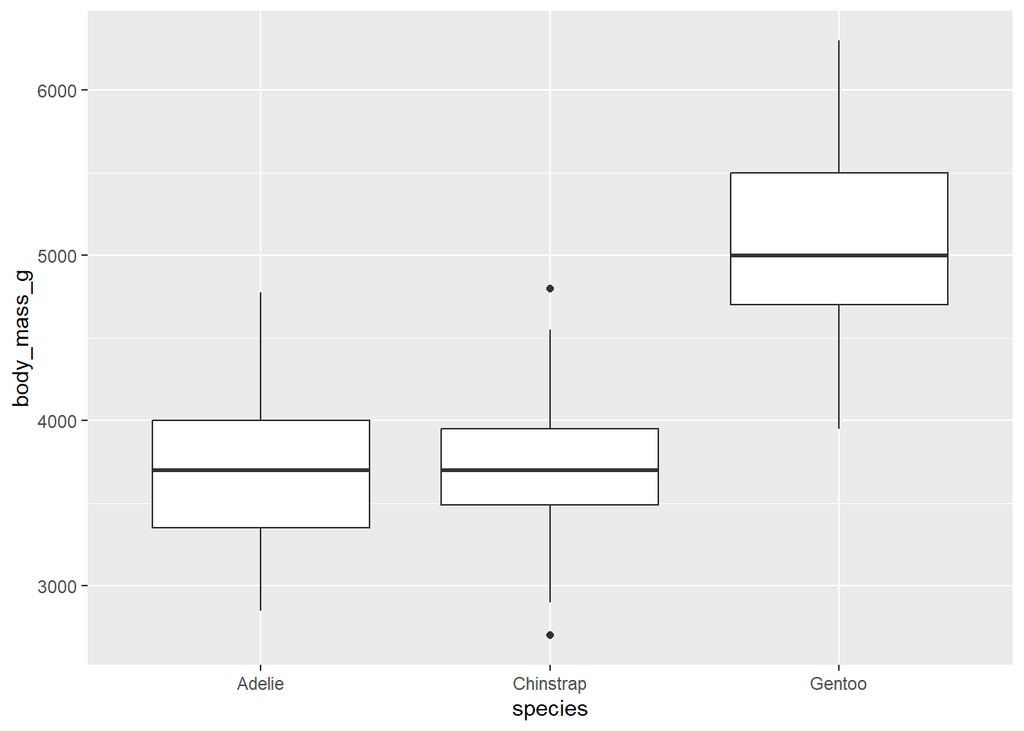

```r
# Gráfico base
penguins_boxplot <- ggplot(data = penguins) +
  geom_boxplot(aes(x = species, y = body_mass_g))

penguins_boxplot
```

Ahora aplicamos la función `labs()` para añadir todos los elementos textuales necesarios: título principal, subtítulo contextual, etiquetas descriptivas para ambos ejes y un pie de figura que indica la fuente de los datos.

```r
penguins_boxplot  +
  labs(title = "Masa corporal de los pingüinos por especie",
       subtitle = "Datos de las tres islas",
       x = "Especie",     y = "Masa corporal (g)",
       caption = "Fuente: palmerpenguins")
```

[figure not shown]

La función `labs()` permite personalizar los textos del gráfico. Es crucial para hacer los gráficos autónomos y comprensibles.